# Flight Delays Data Exploration

## Preliminary Wrangling

This document explores a dataset containing reports of flights in the United States, including carriers, delays, cancellations, and reasons for delays, flights delay causes from June 2003 to January 2021 compound by approximately 294,000 instances.

```python
#Import all packages needed
import numpy as np
import pandas as pd
import matplotlib.pyplot as plt
import seaborn as sb
%matplotlib inline
```

```python
#read de csv file and save database in a variable
flights=pd.read_csv('airline_delay_causes.csv')
```

```python
#Show number of rows, columns names and type, and sow a preview of the dataset with the head() function
print(flights.shape)
print(flights.dtypes)
print(flights.head(10))
```

```
(294237, 22)
year                     int64
 month                   int64
carrier                 object
carrier_name            object
airport                 object
airport_name            object
arr_flights            float64
arr_del15              float64
carrier_ct             float64
 weather_ct            float64
nas_ct                 float64
security_ct            float64
late_aircraft_ct       float64
arr_cancelled          float64
arr_diverted           float64
 arr_delay             float64
 carrier_delay         float64
weather_delay          float64
nas_delay              float64
security_delay         float64
late_aircraft_delay    float64
Unnamed: 21            float64
dtype: object
   year   month carrier          carrier_name airport  \
0  2009      11      AS  Alaska Airlines Inc.     BRW
1  2009      11      AS  Alaska Airlines Inc.     BUR
2  2009      11      AS  Alaska Airlines Inc.     CDV
3  2009      11      AS  Alaska Airlines Inc.     DCA
4  2009      11      AS  Alaska Airlines Inc.     DEN
5  2009      11      AS  Alaska Airlines Inc.     DFW
6  2009      11      AS  Alaska Airlines Inc.     EWR
7  2009      11      AS  Alaska Airlines Inc.     FAI
8  2009      11      AS  Alaska Airlines Inc.     GEG
9  2009      11      AS  Alaska Airlines Inc.     HNL

                                        airport_name  arr_flights  arr_del15  \
0        Barrow, AK: Wiley Post/Will Rogers Memorial         65.0       14.0
1                              Burbank, CA: Bob Hope         85.0        5.0
2                 Cordova, AK: Merle K Mudhole Smith         58.0        8.0
```

[output cut: 30 more lines]

```
9           0.0       547.0            85.0           89.0      373.0

   security_delay  late_aircraft_delay  Unnamed: 21
0             0.0                216.0          NaN
1             0.0                 39.0          NaN
2             0.0                313.0          NaN
3             0.0                  0.0          NaN
4             0.0                  0.0          NaN
5             0.0                  0.0          NaN
6             0.0                 19.0          NaN
7             0.0                703.0          NaN
8             0.0                  0.0          NaN
9             0.0                  0.0          NaN

[10 rows x 22 columns]
```

```python
#Remove unname column
flights.drop(flights.columns[flights.columns.str.contains('Unnamed',case = False)],axis = 1, inplace = True)
#Confirm that was dropped
flights.info()
```

```
<class 'pandas.core.frame.DataFrame'>
RangeIndex: 294237 entries, 0 to 294236
Data columns (total 21 columns):
 #   Column               Non-Null Count   Dtype
---  ------               --------------   -----
 0   year                 294237 non-null  int64
 1    month               294237 non-null  int64
 2   carrier              294237 non-null  object
 3   carrier_name         294237 non-null  object
 4   airport              294237 non-null  object
 5   airport_name         294237 non-null  object
 6   arr_flights          293774 non-null  float64
 7   arr_del15            293548 non-null  float64
 8   carrier_ct           293774 non-null  float64
 9    weather_ct          293774 non-null  float64
 10  nas_ct               293774 non-null  float64
 11  security_ct          293774 non-null  float64
 12  late_aircraft_ct     293774 non-null  float64
 13  arr_cancelled        293774 non-null  float64
 14  arr_diverted         293774 non-null  float64
 15   arr_delay           293774 non-null  float64
 16   carrier_delay       293774 non-null  float64
 17  weather_delay        293774 non-null  float64
 18  nas_delay            293774 non-null  float64
 19  security_delay       293774 non-null  float64
 20  late_aircraft_delay  293774 non-null  float64
dtypes: float64(15), int64(2), object(4)
memory usage: 47.1+ MB
```

```python
#Remove the whitespace in some column names and see if there are duplicated instances
flights.columns = flights.columns.str.replace(' ', '')
print(flights.duplicated().sum())
print(flights.info())
```

```
0
<class 'pandas.core.frame.DataFrame'>
RangeIndex: 294237 entries, 0 to 294236
Data columns (total 21 columns):
 #   Column               Non-Null Count   Dtype
---  ------               --------------   -----
 0   year                 294237 non-null  int64
 1   month                294237 non-null  int64
 2   carrier              294237 non-null  object
 3   carrier_name         294237 non-null  object
 4   airport              294237 non-null  object
 5   airport_name         294237 non-null  object
 6   arr_flights          293774 non-null  float64
 7   arr_del15            293548 non-null  float64
 8   carrier_ct           293774 non-null  float64
 9   weather_ct           293774 non-null  float64
 10  nas_ct               293774 non-null  float64
 11  security_ct          293774 non-null  float64
 12  late_aircraft_ct     293774 non-null  float64
 13  arr_cancelled        293774 non-null  float64
 14  arr_diverted         293774 non-null  float64
 15  arr_delay            293774 non-null  float64
 16  carrier_delay        293774 non-null  float64
 17  weather_delay        293774 non-null  float64
 18  nas_delay            293774 non-null  float64
 19  security_delay       293774 non-null  float64
 20  late_aircraft_delay  293774 non-null  float64
dtypes: float64(15), int64(2), object(4)
memory usage: 47.1+ MB
None
```

```python
#Drop rows with Na values because its quantity is negligible
flights.dropna(inplace=True)
flights.info()
```

```
<class 'pandas.core.frame.DataFrame'>
Int64Index: 293548 entries, 0 to 294236
Data columns (total 21 columns):
 #   Column               Non-Null Count   Dtype
---  ------               --------------   -----
 0   year                 293548 non-null  int64
 1   month                293548 non-null  int64
 2   carrier              293548 non-null  object
 3   carrier_name         293548 non-null  object
 4   airport              293548 non-null  object
 5   airport_name         293548 non-null  object
 6   arr_flights          293548 non-null  float64
 7   arr_del15            293548 non-null  float64
 8   carrier_ct           293548 non-null  float64
 9   weather_ct           293548 non-null  float64
 10  nas_ct               293548 non-null  float64
 11  security_ct          293548 non-null  float64
 12  late_aircraft_ct     293548 non-null  float64
 13  arr_cancelled        293548 non-null  float64
 14  arr_diverted         293548 non-null  float64
 15  arr_delay            293548 non-null  float64
 16  carrier_delay        293548 non-null  float64
 17  weather_delay        293548 non-null  float64
 18  nas_delay            293548 non-null  float64
 19  security_delay       293548 non-null  float64
 20  late_aircraft_delay  293548 non-null  float64
dtypes: float64(15), int64(2), object(4)
memory usage: 49.3+ MB
```

```python
#Create a new column with non-numeric values of months for better visualizations
conditions = [
    (flights['month'] == 1),
    (flights['month'] == 2),
    (flights['month'] == 3),
    (flights['month'] == 4),
    (flights['month'] == 5),
    (flights['month'] == 6),
    (flights['month'] == 7),
    (flights['month'] == 8),
    (flights['month'] == 9),
    (flights['month'] == 10),
    (flights['month'] == 11),
    (flights['month'] == 12)]

values = ['January','Febrary','March','April','May','June','July','August','September','October','November','December']
flights['month_ch'] = np.select(conditions, values)
#display updated DataFrame
flights.head()
```

|  | year | month | carrier | carrier_name | airport | airport_name | arr_flights | arr_del15 | carrier_ct | weather_ct | ... | late_aircraft_ct | arr_cancelled | arr_diverted | arr_delay | carrier_delay | weather_delay | nas_delay | security_delay | late_aircraft_delay | month_ch |
| --- | --- | --- | --- | --- | --- | --- | --- | --- | --- | --- | --- | --- | --- | --- | --- | --- | --- | --- | --- | --- | --- |
| 0 | 2009 | 11 | AS | Alaska Airlines Inc. | BRW | Barrow, AK: Wiley Post/Will Rogers Memorial | 65.0 | 14.0 | 3.61 | 1.06 | ... | 6.19 | 0.0 | 1.0 | 920.0 | 592.0 | 34.0 | 78.0 | 0.0 | 216.0 | November |
| 1 | 2009 | 11 | AS | Alaska Airlines Inc. | BUR | Burbank, CA: Bob Hope | 85.0 | 5.0 | 1.00 | 0.00 | ... | 0.98 | 0.0 | 0.0 | 134.0 | 25.0 | 0.0 | 70.0 | 0.0 | 39.0 | November |
| 2 | 2009 | 11 | AS | Alaska Airlines Inc. | CDV | Cordova, AK: Merle K Mudhole Smith | 58.0 | 8.0 | 2.04 | 1.00 | ... | 2.96 | 4.0 | 2.0 | 586.0 | 174.0 | 37.0 | 62.0 | 0.0 | 313.0 | November |
| 3 | 2009 | 11 | AS | Alaska Airlines Inc. | DCA | Washington, DC: Ronald Reagan Washington National | 88.0 | 11.0 | 1.99 | 0.00 | ... | 0.00 | 0.0 | 0.0 | 266.0 | 65.0 | 0.0 | 201.0 | 0.0 | 0.0 | November |
| 4 | 2009 | 11 | AS | Alaska Airlines Inc. | DEN | Denver, CO: Denver International | 123.0 | 5.0 | 3.47 | 0.00 | ... | 0.00 | 0.0 | 0.0 | 81.0 | 57.0 | 0.0 | 24.0 | 0.0 | 0.0 | November |

5 rows × 22 columns

```python
#keep only information from 2004 and till 2020 to analyse only complete anual data
flights = flights.query("year > 2003 & year < 2021")
```

```python
#Split the values of 'airport_name' into city, state and airport_name
names1 = flights["airport_name"].str.split(",",expand=True)
names1.columns = ['city', 'state&airports_name']
flights.drop('airport_name', axis=1, inplace=True)

names2 = names1["state&airports_name"].str.split(":",expand=True)
names2.columns = ['state', 'airport_name']
names = pd.concat([names1['city'], names2], axis=1)

flights = pd.concat([flights, names], axis=1)
flights.state = flights.state.str.replace(' ', '')
```

```python
#Keep only rows with positive values for numeric numeric columns
flights = flights[flights.select_dtypes(include=[np.number]).ge(0).all(1)]
```

```python
#Calculate percentages of flights thats been delayed, cancelled, diverted, reason of delay and percentage of duration for each delay type
flights["delayed_ratio_ct"] = (flights["arr_del15"] / flights["arr_flights"])*100
flights["cancelled_ratio_ct"] = (flights["arr_cancelled"] / flights["arr_flights"])*100
flights["diverted_ratio_ct"] = (flights["arr_diverted"] / flights["arr_flights"])*100
flights["delaymin_per_flight"] = (flights["arr_delay"] / flights["arr_del15"])

flights["carrier_ratio_ct"] = (flights["carrier_ct"] / flights["arr_del15"])*100
flights["weather_ratio_ct"] = (flights["weather_ct"] / flights["arr_del15"])*100
flights["nas_ratio_ct"] = (flights["nas_ct"] / flights["arr_del15"])*100
flights["security_ratio_ct"] = (flights["security_ct"] / flights["arr_del15"])*100
flights["late_aircraft_ratio_ct"] = (flights["late_aircraft_ct"] / flights["arr_del15"])*100

flights["carrier_dr_min"] = (flights["carrier_delay"] / flights["arr_delay"])*100
flights["weather_dr_min"] = (flights["weather_delay"] / flights["arr_delay"])*100
flights["nas_dr_min"] = (flights["nas_delay"] / flights["arr_delay"])*100
flights["security_dr_min"] = (flights["security_delay"] / flights["arr_delay"])*100
flights["late_aircraft_dr_min"] = (flights["late_aircraft_delay"] / flights["arr_delay"])*100

v=["delayed_ratio_ct","cancelled_ratio_ct","diverted_ratio_ct","delaymin_per_flight","carrier_ratio_ct",
   "weather_ratio_ct","nas_ratio_ct","security_ratio_ct","late_aircraft_ratio_ct","carrier_dr_min","weather_dr_min",
   "nas_dr_min","security_dr_min","late_aircraft_dr_min"]
#There are 3 visualizations that fitt better with na values than with ceros
flights_withNa = flights.copy()

for x in v:
    flights[x] = flights[x].fillna(0)

print(flights.isna().sum())
flights.head()
```

```
year                      0
month                     0
carrier                   0
carrier_name              0
airport                   0
arr_flights               0
arr_del15                 0
carrier_ct                0
weather_ct                0
nas_ct                    0
security_ct               0
late_aircraft_ct          0
arr_cancelled             0
arr_diverted              0
arr_delay                 0
carrier_delay             0
weather_delay             0
nas_delay                 0
security_delay            0
late_aircraft_delay       0
month_ch                  0
city                      0
state                     0
airport_name              0
delayed_ratio_ct          0
cancelled_ratio_ct        0
diverted_ratio_ct         0
delaymin_per_flight       0
carrier_ratio_ct          0
weather_ratio_ct          0
nas_ratio_ct              0
security_ratio_ct         0
late_aircraft_ratio_ct    0
carrier_dr_min            0
weather_dr_min            0
nas_dr_min                0
security_dr_min           0
late_aircraft_dr_min      0
dtype: int64
```

|  | year | month | carrier | carrier_name | airport | arr_flights | arr_del15 | carrier_ct | weather_ct | nas_ct | ... | carrier_ratio_ct | weather_ratio_ct | nas_ratio_ct | security_ratio_ct | late_aircraft_ratio_ct | carrier_dr_min | weather_dr_min | nas_dr_min | security_dr_min | late_aircraft_dr_min |
| --- | --- | --- | --- | --- | --- | --- | --- | --- | --- | --- | --- | --- | --- | --- | --- | --- | --- | --- | --- | --- | --- |
| 0 | 2009 | 11 | AS | Alaska Airlines Inc. | BRW | 65.0 | 14.0 | 3.61 | 1.06 | 3.14 | ... | 25.785714 | 7.571429 | 22.428571 | 0.0 | 44.214286 | 64.347826 | 3.695652 | 8.478261 | 0.0 | 23.478261 |
| 1 | 2009 | 11 | AS | Alaska Airlines Inc. | BUR | 85.0 | 5.0 | 1.00 | 0.00 | 3.03 | ... | 20.000000 | 0.000000 | 60.600000 | 0.0 | 19.600000 | 18.656716 | 0.000000 | 52.238806 | 0.0 | 29.104478 |
| 2 | 2009 | 11 | AS | Alaska Airlines Inc. | CDV | 58.0 | 8.0 | 2.04 | 1.00 | 2.00 | ... | 25.500000 | 12.500000 | 25.000000 | 0.0 | 37.000000 | 29.692833 | 6.313993 | 10.580205 | 0.0 | 53.412969 |
| 3 | 2009 | 11 | AS | Alaska Airlines Inc. | DCA | 88.0 | 11.0 | 1.99 | 0.00 | 9.01 | ... | 18.090909 | 0.000000 | 81.909091 | 0.0 | 0.000000 | 24.436090 | 0.000000 | 75.563910 | 0.0 | 0.000000 |
| 4 | 2009 | 11 | AS | Alaska Airlines Inc. | DEN | 123.0 | 5.0 | 3.47 | 0.00 | 1.53 | ... | 69.400000 | 0.000000 | 30.600000 | 0.0 | 0.000000 | 70.370370 | 0.000000 | 29.629630 | 0.0 | 0.000000 |

5 rows × 38 columns

```python
print(flights['delaymin_per_flight'].describe())
flights.query("delaymin_per_flight>400")
#We will remove this 94 outliers to avoid problems in visualizations
flights = flights.query("delaymin_per_flight<=400")
print(flights['delaymin_per_flight'].describe())
```

```
count    283223.000000
mean         53.233259
std          25.923762
min           0.000000
25%          40.916667
50%          50.875000
75%          62.400000
max        1551.000000
Name: delaymin_per_flight, dtype: float64
count    283129.000000
mean         53.048315
std          23.454075
min           0.000000
25%          40.911184
50%          50.871795
75%          62.384615
max         399.000000
Name: delaymin_per_flight, dtype: float64
```

```python
#Use the melt function and create 2 new datasets to easy the analisis of the delay type count and delay type duration.
fligts_del_ct = flights.melt(id_vars=['year','month','carrier_name','city','state','airport_name','arr_flights'],
                value_vars=['carrier_ct','weather_ct','nas_ct','security_ct','late_aircraft_ct'],
                var_name='delay_type',
                value_name='delayed_ct')

fligts_del_min = flights.melt(id_vars=['year','month','carrier_name','city','state','airport_name','arr_delay'],
                value_vars=['carrier_delay','weather_delay','nas_delay','security_delay','late_aircraft_delay'],
                var_name='delay_type',
                value_name='delayed_min')
```

```python
#Obtain the percentage of flights delayed for each type of delay and replace na with 0
fligts_del_ct["delayed_ct_ratio"] = (fligts_del_ct["delayed_ct"] / fligts_del_ct["arr_flights"])*100
fligts_del_ct
```

|  | year | month | carrier_name | city | state | airport_name | arr_flights | delay_type | delayed_ct | delayed_ct_ratio |
| --- | --- | --- | --- | --- | --- | --- | --- | --- | --- | --- |
| 0 | 2009 | 11 | Alaska Airlines Inc. | Barrow | AK | Wiley Post/Will Rogers Memorial | 65.0 | carrier_ct | 3.61 | 5.553846 |
| 1 | 2009 | 11 | Alaska Airlines Inc. | Burbank | CA | Bob Hope | 85.0 | carrier_ct | 1.00 | 1.176471 |
| 2 | 2009 | 11 | Alaska Airlines Inc. | Cordova | AK | Merle K Mudhole Smith | 58.0 | carrier_ct | 2.04 | 3.517241 |
| 3 | 2009 | 11 | Alaska Airlines Inc. | Washington | DC | Ronald Reagan Washington National | 88.0 | carrier_ct | 1.99 | 2.261364 |
| 4 | 2009 | 11 | Alaska Airlines Inc. | Denver | CO | Denver International | 123.0 | carrier_ct | 3.47 | 2.821138 |
| ... | ... | ... | ... | ... | ... | ... | ... | ... | ... | ... |
| 1415640 | 2018 | 11 | Delta Air Lines Inc. | Syracuse | NY | Syracuse Hancock International | 131.0 | late_aircraft_ct | 7.87 | 6.007634 |
| 1415641 | 2018 | 11 | Delta Air Lines Inc. | Tallahassee | FL | Tallahassee International | 141.0 | late_aircraft_ct | 11.75 | 8.333333 |
| 1415642 | 2018 | 11 | Delta Air Lines Inc. | Tampa | FL | Tampa International | 873.0 | late_aircraft_ct | 55.21 | 6.324170 |
| 1415643 | 2018 | 11 | Delta Air Lines Inc. | Bristol/Johnson City/Kingsport | TN | Tri Cities | 31.0 | late_aircraft_ct | 0.43 | 1.387097 |
| 1415644 | 2018 | 11 | Delta Air Lines Inc. | Tulsa | OK | Tulsa International | 81.0 | late_aircraft_ct | 7.35 | 9.074074 |

1415645 rows × 10 columns

```python
#Obtain the percentage of duration of delayed flights for each type of delay and replace na with 0
fligts_del_min["delayed_min_ratio"] = (fligts_del_min["delayed_min"] / fligts_del_min["arr_delay"])*100
fligts_del_min
```

|  | year | month | carrier_name | city | state | airport_name | arr_delay | delay_type | delayed_min | delayed_min_ratio |
| --- | --- | --- | --- | --- | --- | --- | --- | --- | --- | --- |
| 0 | 2009 | 11 | Alaska Airlines Inc. | Barrow | AK | Wiley Post/Will Rogers Memorial | 920.0 | carrier_delay | 592.0 | 64.347826 |
| 1 | 2009 | 11 | Alaska Airlines Inc. | Burbank | CA | Bob Hope | 134.0 | carrier_delay | 25.0 | 18.656716 |
| 2 | 2009 | 11 | Alaska Airlines Inc. | Cordova | AK | Merle K Mudhole Smith | 586.0 | carrier_delay | 174.0 | 29.692833 |
| 3 | 2009 | 11 | Alaska Airlines Inc. | Washington | DC | Ronald Reagan Washington National | 266.0 | carrier_delay | 65.0 | 24.436090 |
| 4 | 2009 | 11 | Alaska Airlines Inc. | Denver | CO | Denver International | 81.0 | carrier_delay | 57.0 | 70.370370 |
| ... | ... | ... | ... | ... | ... | ... | ... | ... | ... | ... |
| 1415640 | 2018 | 11 | Delta Air Lines Inc. | Syracuse | NY | Syracuse Hancock International | 1261.0 | late_aircraft_delay | 803.0 | 63.679619 |
| 1415641 | 2018 | 11 | Delta Air Lines Inc. | Tallahassee | FL | Tallahassee International | 977.0 | late_aircraft_delay | 589.0 | 60.286592 |
| 1415642 | 2018 | 11 | Delta Air Lines Inc. | Tampa | FL | Tampa International | 9053.0 | late_aircraft_delay | 2824.0 | 31.194079 |
| 1415643 | 2018 | 11 | Delta Air Lines Inc. | Bristol/Johnson City/Kingsport | TN | Tri Cities | 206.0 | late_aircraft_delay | 13.0 | 6.310680 |
| 1415644 | 2018 | 11 | Delta Air Lines Inc. | Tulsa | OK | Tulsa International | 462.0 | late_aircraft_delay | 219.0 | 47.402597 |

1415645 rows × 10 columns

```python
#combine the two melt datasets
fligts_ct_min = fligts_del_ct.copy()
fligts_ct_min['arr_delay'] = fligts_del_min['arr_delay']
fligts_ct_min['delayed_min'] = fligts_del_min['delayed_min']
fligts_ct_min['delayed_min_ratio'] = fligts_del_min['delayed_min_ratio']
fligts_ct_min['delay_type'] = fligts_ct_min['delay_type'].str[:-3]
#Remove NAs
fligts_ct_min["delayed_ct_ratio"] = fligts_ct_min["delayed_ct_ratio"].fillna(0)
fligts_ct_min["delayed_min_ratio"] = fligts_ct_min["delayed_min_ratio"].fillna(0)
fligts_ct_min
```

|  | year | month | carrier_name | city | state | airport_name | arr_flights | delay_type | delayed_ct | delayed_ct_ratio | arr_delay | delayed_min | delayed_min_ratio |
| --- | --- | --- | --- | --- | --- | --- | --- | --- | --- | --- | --- | --- | --- |
| 0 | 2009 | 11 | Alaska Airlines Inc. | Barrow | AK | Wiley Post/Will Rogers Memorial | 65.0 | carrier | 3.61 | 5.553846 | 920.0 | 592.0 | 64.347826 |
| 1 | 2009 | 11 | Alaska Airlines Inc. | Burbank | CA | Bob Hope | 85.0 | carrier | 1.00 | 1.176471 | 134.0 | 25.0 | 18.656716 |
| 2 | 2009 | 11 | Alaska Airlines Inc. | Cordova | AK | Merle K Mudhole Smith | 58.0 | carrier | 2.04 | 3.517241 | 586.0 | 174.0 | 29.692833 |
| 3 | 2009 | 11 | Alaska Airlines Inc. | Washington | DC | Ronald Reagan Washington National | 88.0 | carrier | 1.99 | 2.261364 | 266.0 | 65.0 | 24.436090 |
| 4 | 2009 | 11 | Alaska Airlines Inc. | Denver | CO | Denver International | 123.0 | carrier | 3.47 | 2.821138 | 81.0 | 57.0 | 70.370370 |
| ... | ... | ... | ... | ... | ... | ... | ... | ... | ... | ... | ... | ... | ... |
| 1415640 | 2018 | 11 | Delta Air Lines Inc. | Syracuse | NY | Syracuse Hancock International | 131.0 | late_aircraft | 7.87 | 6.007634 | 1261.0 | 803.0 | 63.679619 |
| 1415641 | 2018 | 11 | Delta Air Lines Inc. | Tallahassee | FL | Tallahassee International | 141.0 | late_aircraft | 11.75 | 8.333333 | 977.0 | 589.0 | 60.286592 |
| 1415642 | 2018 | 11 | Delta Air Lines Inc. | Tampa | FL | Tampa International | 873.0 | late_aircraft | 55.21 | 6.324170 | 9053.0 | 2824.0 | 31.194079 |
| 1415643 | 2018 | 11 | Delta Air Lines Inc. | Bristol/Johnson City/Kingsport | TN | Tri Cities | 31.0 | late_aircraft | 0.43 | 1.387097 | 206.0 | 13.0 | 6.310680 |
| 1415644 | 2018 | 11 | Delta Air Lines Inc. | Tulsa | OK | Tulsa International | 81.0 | late_aircraft | 7.35 | 9.074074 | 462.0 | 219.0 | 47.402597 |

1415645 rows × 13 columns

```python
print(flights.shape)
print(flights.info())
print(flights.describe())
```

```
(283129, 38)
<class 'pandas.core.frame.DataFrame'>
Int64Index: 283129 entries, 0 to 294236
Data columns (total 38 columns):
 #   Column                  Non-Null Count   Dtype
---  ------                  --------------   -----
 0   year                    283129 non-null  int64
 1   month                   283129 non-null  int64
 2   carrier                 283129 non-null  object
 3   carrier_name            283129 non-null  object
 4   airport                 283129 non-null  object
 5   arr_flights             283129 non-null  float64
 6   arr_del15               283129 non-null  float64
 7   carrier_ct              283129 non-null  float64
 8   weather_ct              283129 non-null  float64
 9   nas_ct                  283129 non-null  float64
 10  security_ct             283129 non-null  float64
 11  late_aircraft_ct        283129 non-null  float64
 12  arr_cancelled           283129 non-null  float64
 13  arr_diverted            283129 non-null  float64
 14  arr_delay               283129 non-null  float64
 15  carrier_delay           283129 non-null  float64
 16  weather_delay           283129 non-null  float64
 17  nas_delay               283129 non-null  float64
 18  security_delay          283129 non-null  float64
 19  late_aircraft_delay     283129 non-null  float64
 20  month_ch                283129 non-null  object
 21  city                    283129 non-null  object
 22  state                   283129 non-null  object
 23  airport_name            283129 non-null  object
 24  delayed_ratio_ct        283129 non-null  float64
 25  cancelled_ratio_ct      283129 non-null  float64
 26  diverted_ratio_ct       283129 non-null  float64
 27  delaymin_per_flight     283129 non-null  float64
 28  carrier_ratio_ct        283129 non-null  float64
 29  weather_ratio_ct        283129 non-null  float64
 30  nas_ratio_ct            283129 non-null  float64
 31  security_ratio_ct       283129 non-null  float64
 32  late_aircraft_ratio_ct  283129 non-null  float64
 33  carrier_dr_min          283129 non-null  float64
```

[output cut: 53 more lines]

```
50%                 28.520000       34.415584        1.460823      17.979003
75%                 41.071142       49.203980        6.832075      29.891304
max                100.000000      100.000000      100.000000     100.000000

       security_dr_min  late_aircraft_dr_min
count    283129.000000         283129.000000
mean          0.198221             32.195730
std           1.720446             21.591683
min           0.000000              0.000000
25%           0.000000             15.178571
50%           0.000000             32.412432
75%           0.000000             47.151899
max         100.000000            100.000000

[8 rows x 31 columns]
```

```python
print(fligts_ct_min.shape)
print(fligts_ct_min.info())
print(fligts_ct_min.describe())
```

```
(1415645, 13)
<class 'pandas.core.frame.DataFrame'>
RangeIndex: 1415645 entries, 0 to 1415644
Data columns (total 13 columns):
 #   Column             Non-Null Count    Dtype
---  ------             --------------    -----
 0   year               1415645 non-null  int64
 1   month              1415645 non-null  int64
 2   carrier_name       1415645 non-null  object
 3   city               1415645 non-null  object
 4   state              1415645 non-null  object
 5   airport_name       1415645 non-null  object
 6   arr_flights        1415645 non-null  float64
 7   delay_type         1415645 non-null  object
 8   delayed_ct         1415645 non-null  float64
 9   delayed_ct_ratio   1415645 non-null  float64
 10  arr_delay          1415645 non-null  float64
 11  delayed_min        1415645 non-null  float64
 12  delayed_min_ratio  1415645 non-null  float64
dtypes: float64(6), int64(2), object(5)
memory usage: 140.4+ MB
None
               year         month   arr_flights    delayed_ct  \
count  1.415645e+06  1.415645e+06  1.415645e+06  1.415645e+06
mean   2.011909e+03  6.492821e+00  3.870290e+02  1.489820e+01
std    5.051070e+00  3.454741e+00  1.037487e+03  5.731245e+01
min    2.004000e+03  1.000000e+00  1.000000e+00  0.000000e+00
25%    2.007000e+03  3.000000e+00  6.000000e+01  0.000000e+00
50%    2.012000e+03  6.000000e+00  1.220000e+02  2.170000e+00
75%    2.017000e+03  9.000000e+00  2.770000e+02  9.890000e+00
max    2.020000e+03  1.200000e+01  2.197700e+04  4.091270e+03

       delayed_ct_ratio     arr_delay   delayed_min  delayed_min_ratio
count      1.415645e+06  1.415645e+06  1.415645e+06       1.415645e+06
mean       3.994182e+00  4.284306e+03  8.568607e+02       1.945473e+01
std        5.310290e+00  1.270313e+04  3.532256e+03       2.209962e+01
min        0.000000e+00  0.000000e+00  0.000000e+00       0.000000e+00
25%        0.000000e+00  4.550000e+02  0.000000e+00       0.000000e+00
50%        2.177570e+00  1.241000e+03  1.090000e+02       1.200000e+01
75%        6.298918e+00  3.146000e+03  5.280000e+02       3.318681e+01
max        1.000000e+02  4.336870e+05  2.384400e+05       1.000000e+02
```

### What is the structure of your dataset?

There are 283,129 instances of delayed flight statistics in the dataset with 15 features. Most variables are numeric in nature, but the variables carrier, carrier_name, airport, airport_name, city and state are nominal categorical variables.

### What is/are the main feature(s) of interest in your dataset?

The main features of interest are the quantity & durations of flights delayed, and also the distribution of types of delays along months and years. Also breifly determine which states and carriers have more delayed flights and more delayed time in minutes.

### What features in the dataset do you think will help support your investigation into your feature(s) of interest?

I expect that the new categorical variable delay_type obtained in the dataset fligts_ct_min will help to study the distribution od delay types. The quantity of delayed flights and its duration study will be done with it original variables and the rations in % obtained during the data wrangler steps.

## Univariate Exploration

In this section, I will investigate the distributions of count of flights delayed, durations of delays, flight cancellations and divertions, and the ratios obtained from these.

### Which is the distribution for the durations of delayed flights per observation?

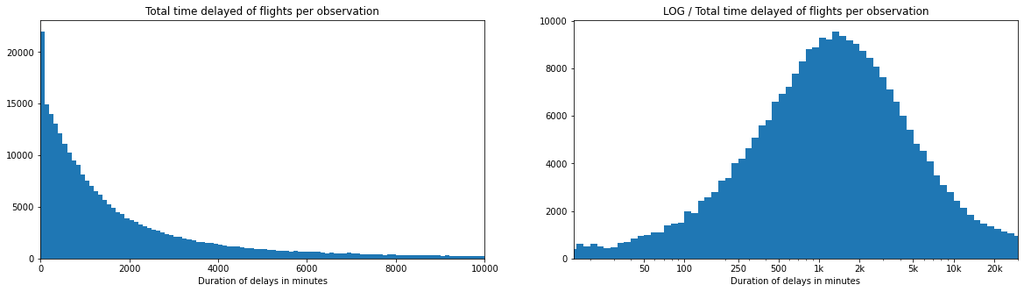

```python
#plot with normal scale
base_color=sb.color_palette()[0]
binsize = 100
bins1 = np.arange(0, flights['arr_delay'].max()+binsize, binsize)
log_binsize = 0.05
bins2 = 10 ** np.arange(0, np.log10(flights['arr_delay'].max())+log_binsize, log_binsize)

plt.figure(figsize = [20, 5])
plt.subplot(1, 2, 1)
plt.hist(data=flights,x='arr_delay',color=base_color, bins=bins1)
plt.title('Total time delayed of flights per observation')
plt.xlabel('Duration of delays in minutes')
plt.xlim([0,1e4]);

plt.subplot(1, 2, 2)
plt.hist(data=flights,x='arr_delay',color=base_color, bins=bins2)
plt.title('LOG / Total time delayed of flights per observation')
plt.xlabel('Duration of delays in minutes')
plt.xscale('log')
plt.xlim([15,3e4])
plt.xticks([50, 100, 250, 500, 1e3, 2e3, 5e3, 1e4, 2e4], [50, 100, 250, 500,'1k', '2k', '5k', '10k', '20k']);
```

With the log scale its visible a normal distribution. The mean duration of delayed flights per observation is between 1000 y 2000 minutes.

### Which is the distribution of the number of flights delayed for more than 15 min per observation?

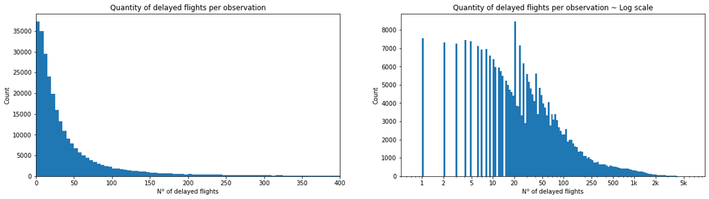

```python
#Plot with normal scale
binsize = 5
bins1 = np.arange(0, flights['arr_del15'].max()+binsize, binsize)
log_binsize = 0.025
bins2 = 10 ** np.arange(0, np.log10(flights['arr_del15'].max())+log_binsize, log_binsize)

plt.figure(figsize = [20, 5])
plt.subplot(1, 2, 1)
plt.hist(data=flights,x='arr_del15',color=base_color, bins=bins1)
plt.xlim([0,4e2])
plt.title('Quantity of delayed flights per observation')
plt.xlabel('N° of delayed flights')
plt.ylabel('Count')

plt.subplot(1, 2, 2)
plt.hist(data=flights,x='arr_del15',color=base_color, bins=bins2)
plt.xscale('log')
plt.xlim([0.5,1e4])
plt.title('Quantity of delayed flights per observation ~ Log scale')
plt.xlabel('N° of delayed flights')
plt.ylabel('Count')
plt.xticks([1,2, 5, 10, 20, 50, 100, 250, 500, 1e3, 2e3, 5e3], [1,2, 5, 10, 20, 50, 100, 250, 500,'1k','2k','5k']);
```

Again, the behaviour of the variable is only visible with a log scale. The first peak is in 1 flight and the frequency begins to decrease until the 20 delayed flights where it start to decrease again, this being the most frecuent value.

Now, using, the variable created from the two plotted before:

### Which is the distribution for the durations of delays per delayed flight?

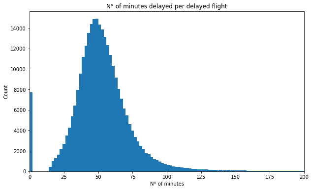

```python
binsize=2
bins = np.arange(0, flights['delaymin_per_flight'].max()+binsize, binsize)

plt.figure(figsize = [10, 6])
plt.hist(data=flights,x='delaymin_per_flight',color=base_color, bins=bins)
plt.title('N° of minutes delayed per delayed flight')
plt.xlabel('N° of minutes')
plt.ylabel('Count')
plt.xlim(0,200);
```

In the above graph is plotted the duration of delay/number of flights delayed for more than 15 minutes. Without cosidering the cero values, the new variable has a normal distribution with a mean around 50 minutes.

### Which is the distribution for the % of delayed flights per instance?

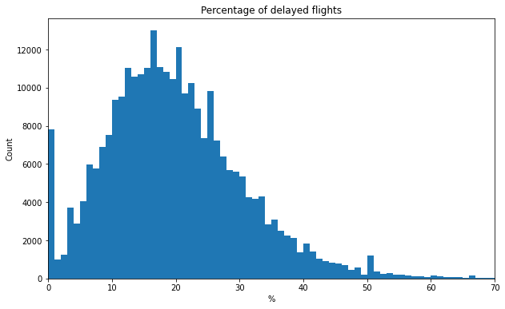

```python
binsize=1
bins = np.arange(0, flights['delayed_ratio_ct'].max()+binsize, binsize)

plt.figure(figsize = [10, 6])
plt.hist(data=flights,x='delayed_ratio_ct',color=base_color, bins=bins)
plt.title('Percentage of delayed flights')
plt.xlabel('%')
plt.ylabel('Count')
plt.xlim(0,70);
```

### Which is the distribution for the number of cancelled flights per instance?

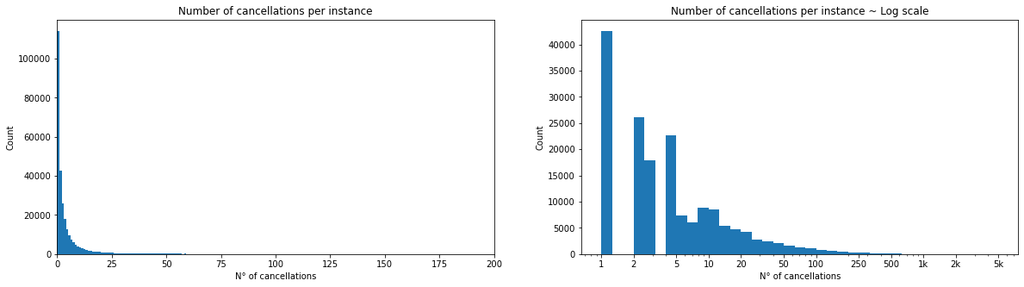

```python
binsize=1
bins1 = np.arange(0, flights['arr_cancelled'].max()+binsize, binsize)
log_binsize = 0.1
bins2 = 10**np.arange(0, np.log10(flights['arr_cancelled'].max())+log_binsize, log_binsize)

plt.figure(figsize = [20, 5])
plt.subplot(1, 2, 1)
plt.hist(data=flights,x='arr_cancelled',color=base_color, bins=bins1);
plt.title('Number of cancellations per instance')
plt.xlabel('N° of cancellations')
plt.ylabel('Count')
plt.xlim(0,2e2);

plt.subplot(1, 2, 2)
plt.hist(data=flights,x='arr_cancelled',color=base_color, bins=bins2);
plt.title('Number of cancellations per instance ~ Log scale')
plt.xlabel('N° of cancellations')
plt.ylabel('Count');
plt.xscale('log')
plt.xticks([1,2, 5, 10, 20, 50, 100, 250, 500, 1e3, 2e3, 5e3], [1,2, 5, 10, 20, 50, 100, 250, 500,'1k','2k','5k']);
```

For the case of the variable of number of cancellations per observation, the behaviour is exponencially decreasing from 0 cancellations.

### Which is the distribution for the % of cancelled flights per instance?

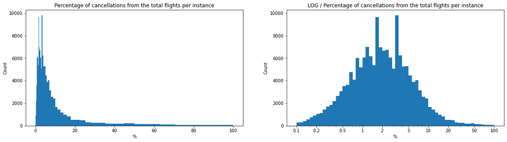

```python
binsize=1
bins = np.arange(0, flights['cancelled_ratio_ct'].max()+binsize, binsize)
log_binsize = 0.05
bins = 10**np.arange(-1, np.log10(flights['cancelled_ratio_ct'].max())+log_binsize, log_binsize)

plt.figure(figsize = [20, 5])
plt.subplot(1, 2, 1)
plt.hist(data=flights,x='cancelled_ratio_ct',color=base_color, bins=bins);
plt.title('Percentage of cancellations from the total flights per instance')
plt.xlabel('%')
plt.ylabel('Count');

plt.subplot(1, 2, 2)
plt.hist(data=flights,x='cancelled_ratio_ct',color=base_color, bins=bins);
plt.title('LOG / Percentage of cancellations from the total flights per instance')
plt.xlabel('%')
plt.ylabel('Count');
plt.xscale('log')
plt.xticks([0.1,0.2,0.5,1,2, 5, 10, 20, 50, 100], [0.1,0.2,0.5,1,2, 5, 10, 20, 50, 100]);
```

Thanks to the logarithmic scale transformation, a bimodal normal distribution can be seen with two peaks at 1.8% and 3.5% of cancellations.

### Which is the distribution for the number of diverted flights per instance?

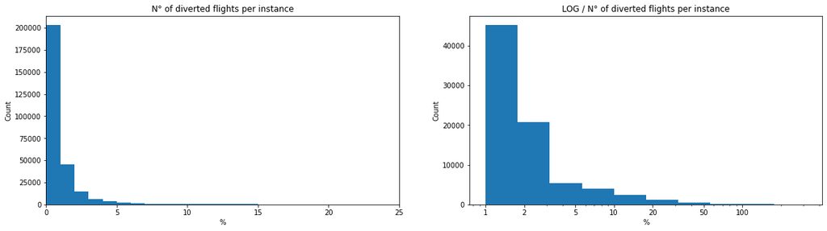

```python
binsize=1
bins1 = np.arange(0, flights['arr_diverted'].max()+binsize, binsize)
log_binsize = 0.25
bins2 = 10**np.arange(0, np.log10(flights['arr_diverted'].max())+log_binsize, log_binsize)

plt.figure(figsize = [20, 5])
plt.subplot(1, 2, 1)
plt.hist(data=flights,x='arr_diverted',color=base_color, bins=bins1);
plt.xlim([0,25])
plt.title('N° of diverted flights per instance')
plt.xlabel('%')
plt.ylabel('Count');

plt.subplot(1, 2, 2)
plt.hist(data=flights,x='arr_diverted',color=base_color, bins=bins2);
plt.title('LOG / N° of diverted flights per instance')
plt.xlabel('%')
plt.ylabel('Count');
plt.xscale('log')
plt.xticks([1,2, 5, 10, 20, 50, 100], [1,2, 5, 10, 20, 50, 100]);
```

Like the number of cancellations, the visualization of the number of diverted flights does not by itself provide much information except that it decreases exponentially. It seems that a plot of the % of diverted flights will be more useful.

### Which is the distribution for the % of diverted flights per instance?

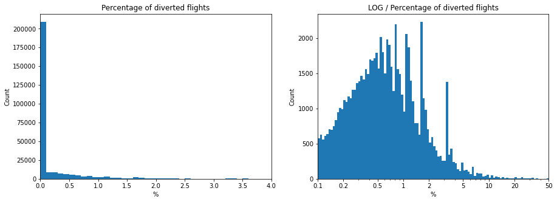

```python
binsize=0.1
bins1 = np.arange(0, flights['diverted_ratio_ct'].max()+binsize, binsize)
log_binsize = 0.025
bins2 = 10**np.arange(-1, np.log10(flights['diverted_ratio_ct'].max())+log_binsize, log_binsize)

plt.figure(figsize = [15, 5])
plt.subplot(1, 2, 1)
plt.hist(data=flights,x='diverted_ratio_ct',color=base_color, bins=bins1);
plt.xlim([0,4])
plt.title('Percentage of diverted flights')
plt.xlabel('%')
plt.ylabel('Count');

plt.subplot(1, 2, 2)
plt.hist(data=flights,x='diverted_ratio_ct',color=base_color, bins=bins2);
plt.title('LOG / Percentage of diverted flights')
plt.xlabel('%')
plt.ylabel('Count');
plt.xscale('log')
plt.xlim([0.1,50])
plt.xticks([0.1,0.2,0.5,1,2, 5, 10, 20, 50], [0.1,0.2,0.5,1,2, 5, 10, 20, 50]);
```

As thought with the visualization above, a chart of its % reveals much more information. A normal distribution can be partially appreciated with several isolated peaks after 0.5%, at 0.7%, 1.2%, 1.7% and 3.2% of diverted flights, to later decrease to the minimum frequency of 0.

### Discuss the distribution(s) of your variable(s) of interest. Were there any unusual points? Did you need to perform any transformations?

Most of the variables needed a logaritmic transformation to appreciate better its distribution. The % graphs of each variable provided much more information than those of the original variables.

### Of the features you investigated, were there any unusual distributions? Did you perform any operations on the data to tidy, adjust, or change the form of the data? If so, why did you do this?

The only unusual aspect was the number of flights delayed more than 15 minutes, as it presented two decay curves, one from 1 and another from 20 delayed flights. The modifications were made on the data wrangler steps with the calculation of ratios of the original variables of flights delayed, cancelled and diverted, with other modications on the dataset to foresee outliers.

## Bivariate Exploration

To start off with, I want to look at the pairwise correlations present between features in the data. First i will isolate the numeric variables for the correlation plot.

```python
flights.columns
```

```
Index(['year', 'month', 'carrier', 'carrier_name', 'airport', 'arr_flights',
       'arr_del15', 'carrier_ct', 'weather_ct', 'nas_ct', 'security_ct',
       'late_aircraft_ct', 'arr_cancelled', 'arr_diverted', 'arr_delay',
       'carrier_delay', 'weather_delay', 'nas_delay', 'security_delay',
       'late_aircraft_delay', 'month_ch', 'city', 'state', 'airport_name',
       'delayed_ratio_ct', 'cancelled_ratio_ct', 'diverted_ratio_ct',
       'delaymin_per_flight', 'carrier_ratio_ct', 'weather_ratio_ct',
       'nas_ratio_ct', 'security_ratio_ct', 'late_aircraft_ratio_ct',
       'carrier_dr_min', 'weather_dr_min', 'nas_dr_min', 'security_dr_min',
       'late_aircraft_dr_min'],
      dtype='object')
```

```python
numeric_vars = ['year', 'month', 'arr_flights',
       'arr_del15', 'carrier_ct', 'weather_ct', 'nas_ct', 'security_ct',
       'late_aircraft_ct', 'arr_cancelled', 'arr_diverted', 'arr_delay',
       'carrier_delay', 'weather_delay', 'nas_delay', 'security_delay',
       'late_aircraft_delay','delayed_ratio_ct', 'cancelled_ratio_ct',
       'diverted_ratio_ct','delaymin_per_flight','carrier_ratio_ct',
       'weather_ratio_ct', 'nas_ratio_ct', 'security_ratio_ct',
       'late_aircraft_ratio_ct', 'carrier_dr_min', 'weather_dr_min',
       'nas_dr_min', 'security_dr_min', 'late_aircraft_dr_min']

categoric_vars = ['carrier', 'carrier_name', 'month_ch', 'airport','city', 'state', 'airport_name']
```

### Correlation plot

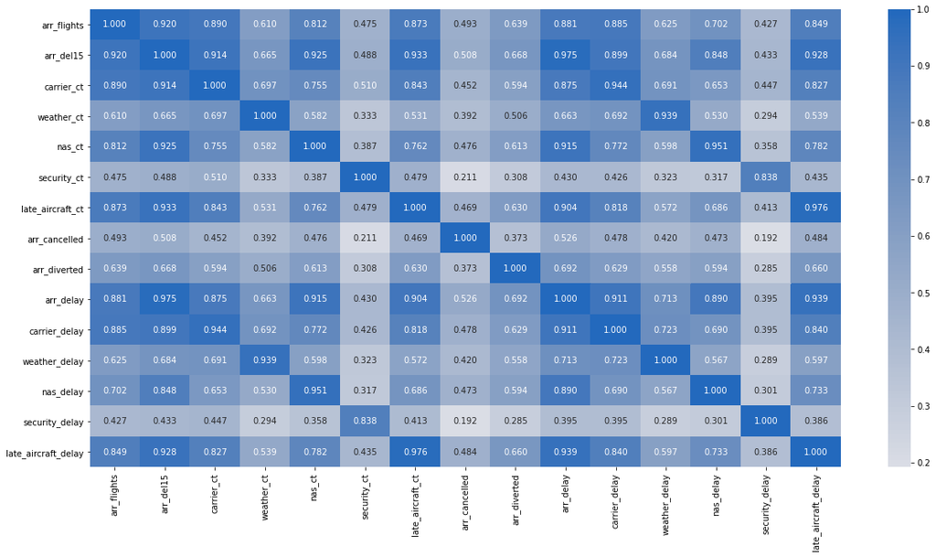

```python
plt.figure(figsize = [20, 10])
sb.heatmap(flights[numeric_vars[2:17]].corr(), annot = True, fmt = '.3f', cmap = 'vlag_r', center = 0);
```

Apart from the obvious relationships between the number of delayed flights and the number of minutes delayed for the same reason (for example: carrier_ct & carrier_delay), there are some relations that need to be further analized with scatterplots.

Now lets make a scatterplot with each set of variables.

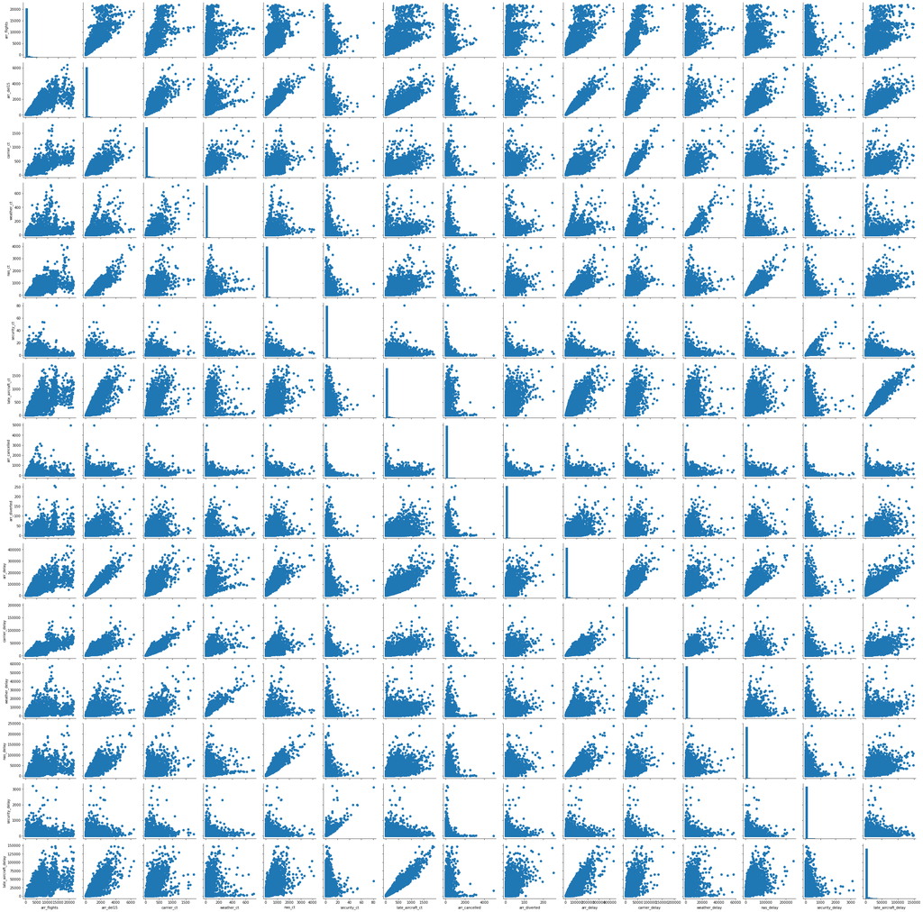

```python
g = sb.PairGrid(data = flights, vars = numeric_vars[2:17])
g = g.map_diag(plt.hist, bins = 20);
g.map_offdiag(plt.scatter);
```

The strongest relationships that can be visualized in the scatter plot are the number of flights delayed for more than 15 minutes (arr_del15) with the total number of flights (arr_flights) and with the variables related to late_aircraft, carrier and nas. On the contrary, there is a weak relationship with the related variables weather and security. This same relationship can be seen with respect to the duration of the delays (arr_delay).

### How is the behaviour of the % of delayed, diverted & cancelled flights along each month?

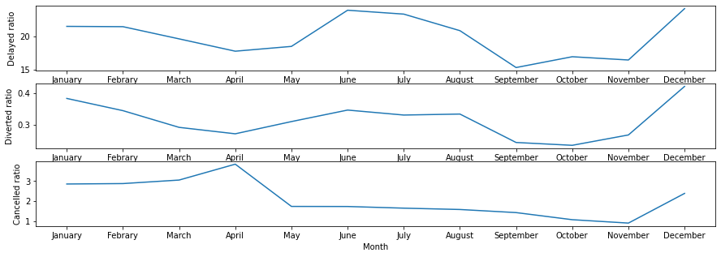

```python
month_DeR=flights.groupby('month')['delayed_ratio_ct'].mean().values
month_CR=flights.groupby('month')['cancelled_ratio_ct'].mean().values
month_DiR=flights.groupby('month')['diverted_ratio_ct'].mean().values
month_order=['January','Febrary','March','April','May','June','July','August','September','October','November','December']

fig, ax = plt.subplots(nrows=3, figsize = [15,5])

ax[0].plot(month_order, month_DeR, color=base_color)
ax[0].set_ylabel('Delayed ratio')

ax[1].plot(month_order, month_DiR, color=base_color)
ax[1].set_ylabel('Diverted ratio')

ax[2].plot(month_order, month_CR, color=base_color)
ax[2].set_ylabel('Cancelled ratio')
ax[2].set_xlabel('Month');
```

The percentage of delayed and diverted flights behave similarly on different scales. While, regarding the percentage of cancellations, there is a large increase while in the other variables there is a decrease in that same month. All variables show an increase during December, January and February.

### Which is the number of delayed flights & the mean duration of delayed flights, both by type of delay?

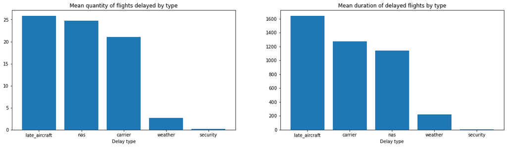

```python
x1=fligts_ct_min.groupby('delay_type')['delayed_ct'].mean().sort_values(ascending=False).index.values
y1=fligts_ct_min.groupby('delay_type')['delayed_ct'].mean().sort_values(ascending=False).values
x2=fligts_ct_min.groupby('delay_type')['delayed_min'].mean().sort_values(ascending=False).index.values
y2=fligts_ct_min.groupby('delay_type')['delayed_min'].mean().sort_values(ascending=False).values

plt.figure(figsize = [20, 5])
plt.subplot(1, 2, 1)
plt.bar(x1,y1)
plt.title('Mean quantity of flights delayed by type')
plt.xlabel('Delay type');

plt.subplot(1, 2, 2)
plt.bar(x2,y2)
plt.title('Mean duration of delayed flights by type')
plt.xlabel('Delay type');
```

The late_aircraft is the type of delay that occurs more times and whose durations are longer than the rest on average. On the other hand, security and weather remain as the reasons for the least occurrence and as the shortest delays. Something interesting happens with the nas and carrier types because on average a greater number of flights are delayed for nas reasons but the durations of delays per carrier are longer on average.

### How is distribution for the count of delay-types for delayed flights by year?

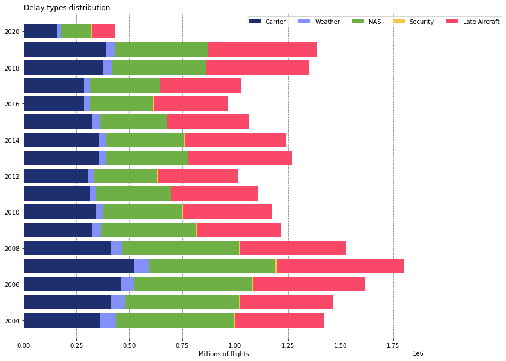

```python
flights_year = flights_withNa.groupby('year').sum()[['carrier_ct','weather_ct','nas_ct','security_ct','late_aircraft_ct']]
flights_year

fields = ['carrier_ct','weather_ct','nas_ct','security_ct','late_aircraft_ct']
colors = ['#1D2F6F', '#8390FA', '#6EAF46', '#FAC748','#FA4869']
labels = ['Carrier', 'Weather', 'NAS', 'Security','Late Aircraft']
# figure and axis
fig, ax = plt.subplots(1, figsize=(12, 10))
# plot bars
left = len(flights_year) * [0]
for idx, name in enumerate(fields):
    plt.barh(flights_year.index, flights_year[name], left = left, color=colors[idx])
    left = left + flights_year[name]
# title, legend, labels
plt.title('Delay types distribution', loc='left')
plt.legend(labels, bbox_to_anchor=([0.55, 1, 0, 0]), ncol=5, frameon=True, loc=2)
plt.xlabel('Millions of flights')
# remove spines
ax.spines['right'].set_visible(False)
ax.spines['left'].set_visible(False)
ax.spines['top'].set_visible(False)
ax.spines['bottom'].set_visible(False)
# adjust limits and draw grid lines
plt.ylim(2003, 2021)
ax.set_axisbelow(True)
ax.xaxis.grid(color='gray', linestyle='dashed')
plt.show()
```

First of all, broadly speaking, there is a decrease in the number of delayed flights for most of the causes of delay. This could be due to a logistical improvement over time, especially referring to the type of delay nas. The low number of delays throughout 2020 is due to the low number of flights made as a cause of the covid-19 pandemic.

Now, speaking of the variables more specifically, it can be seen that delays by late_aircrat, nas and weather decreased in quantity until 2017, to increase considerably in 2018 and 2019, while precisely in these years there were zero amounts of delayed flights for security.

### How is distribution for the % of delay-types for delayed flights by year? and by month?

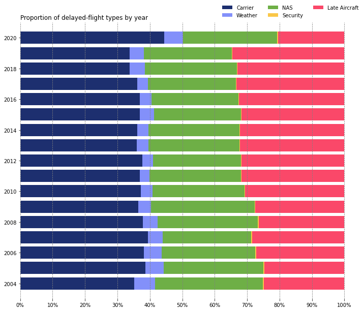

```python
# dataset & variables
flights_year = flights_withNa.groupby('year').mean()[['carrier_ratio_ct','weather_ratio_ct','nas_ratio_ct','security_ratio_ct','late_aircraft_ratio_ct']]
labels = ['Carrier', 'Weather', 'NAS', 'Security','Late Aircraft']
colors = ['#1D2F6F', '#8390FA', '#6EAF46', '#FAC748','#FA4869']
title = 'Proportion of delayed-flight types by year'

def plot_stackedbar_p(df, labels, colors, title):
    fields = df.columns.tolist()
    # figure and axis
    fig, ax = plt.subplots(1, figsize=(12, 10))
    # plot bars
    left = len(df) * [0]
    for idx, name in enumerate(fields):
        plt.barh(df.index, df[name], left = left, color=colors[idx])
        left = left + df[name]
    # title and subtitle
    plt.title(title, loc='left')
    # legend
    plt.legend(labels, bbox_to_anchor=([0.58, 1, 0, 0]), ncol=3, frameon=False, loc='best')
    # remove spines
    ax.spines['right'].set_visible(False)
    ax.spines['left'].set_visible(False)
    ax.spines['top'].set_visible(False)
    ax.spines['bottom'].set_visible(False)
    # format x ticks
    xticks = np.arange(0,110,10)
    xlabels = ['{}%'.format(i) for i in np.arange(0,110,10)]
    plt.xticks(xticks, xlabels)
    # adjust limits and draw grid lines
    plt.ylim(2003,2021)
    ax.xaxis.grid(color='gray', linestyle='dashed')

plot_stackedbar_p(flights_year, labels, colors, title)
```

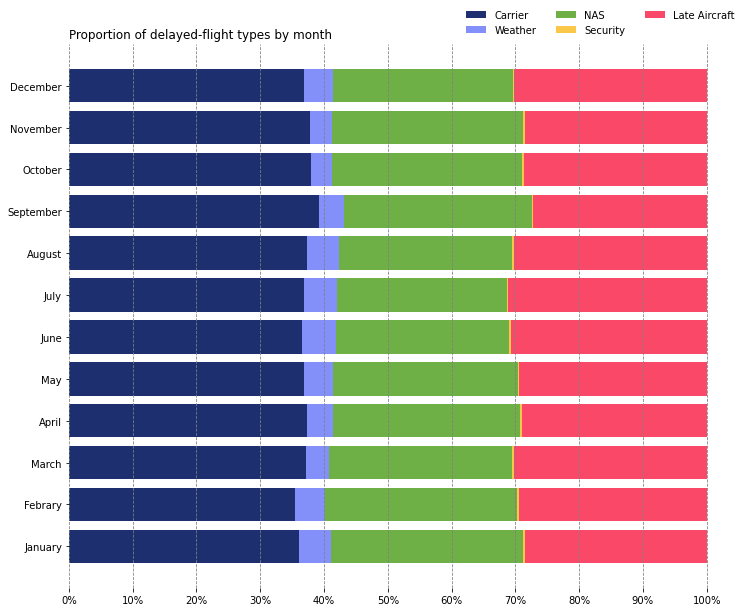

```python
# dataset & variables
flights_month = flights_withNa.groupby('month_ch').mean()[['month','carrier_ratio_ct','weather_ratio_ct','nas_ratio_ct','security_ratio_ct','late_aircraft_ratio_ct']].sort_values('month')
flights_month = flights_month.drop('month',axis=1)

labels = ['Carrier', 'Weather', 'NAS', 'Security','Late Aircraft']
colors = ['#1D2F6F', '#8390FA', '#6EAF46', '#FAC748','#FA4869']
title = 'Proportion of delayed-flight types by month'

def plot_stackedbar_p(df, labels, colors, title):
    fields = df.columns.tolist()
    # figure and axis
    fig, ax = plt.subplots(1, figsize=(12, 10))
    # plot bars
    left = len(df) * [0]
    for idx, name in enumerate(fields):
        plt.barh(df.index, df[name], left = left, color=colors[idx])
        left = left + df[name]
    # title and subtitle
    plt.title(title, loc='left')
    # legend
    plt.legend(labels, bbox_to_anchor=([0.58, 1, 0, 0]), ncol=3, frameon=False, loc='best')
    # remove spines
    ax.spines['right'].set_visible(False)
    ax.spines['left'].set_visible(False)
    ax.spines['top'].set_visible(False)
    ax.spines['bottom'].set_visible(False)
    # format x ticks
    xticks = np.arange(0,110,10)
    xlabels = ['{}%'.format(i) for i in np.arange(0,110,10)]
    plt.xticks(xticks, xlabels)
    # adjust limits and draw grid lines
    ax.xaxis.grid(color='gray', linestyle='dashed')

plot_stackedbar_p(flights_month, labels, colors, title)
```

The annual graph shows an abrupt rise in delays with respect to carrier and nas, a direct consequence of the pandemic as more exhaustive sanitation protocols were added. This is justified with a lower number of delayed flights by late_aircraft since due to the pandemic the number of flights has been abysmally reduced and there is not so much demand so there are more unoccupied planes. You can also see a steady increase in the number of delays caused by late_aircraft until 2019.

https://towardsdatascience.com/stacked-bar-charts-with-pythons-matplotlib-f4020e4eb4a7

### Which are the states with the most and least % of delayed flights?

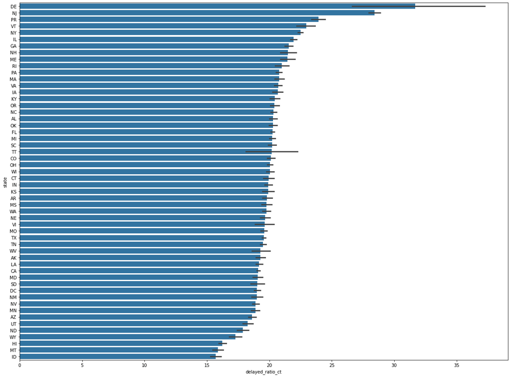

```python
order_DRstate = flights.groupby('state')['delayed_ratio_ct'].mean().sort_values(ascending=False).index.values

plt.figure(figsize = [20, 15])
sb.barplot(data=flights,  y='state',x='delayed_ratio_ct', color=base_color, order=order_DRstate);
```

### Which are the states with the most and least % of cancelled flights?

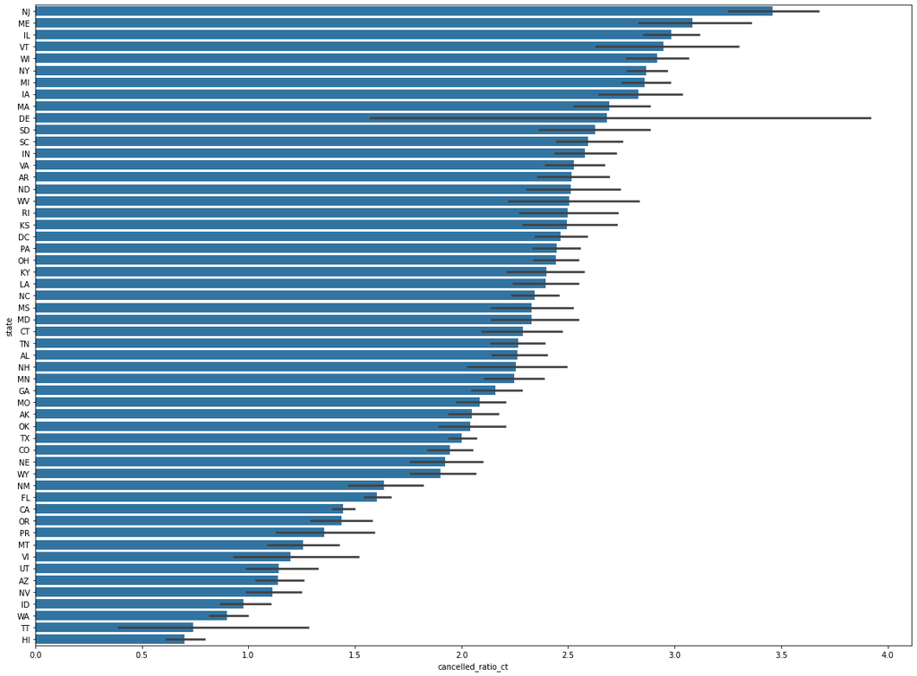

```python
order_CRstate = flights.groupby('state')['cancelled_ratio_ct'].mean().sort_values(ascending=False).index.values

plt.figure(figsize = [20, 15])
sb.barplot(data=flights,  y='state',x='cancelled_ratio_ct', color=base_color, order=order_CRstate);
```

### Which are the states with the most and least % of diverted flights?

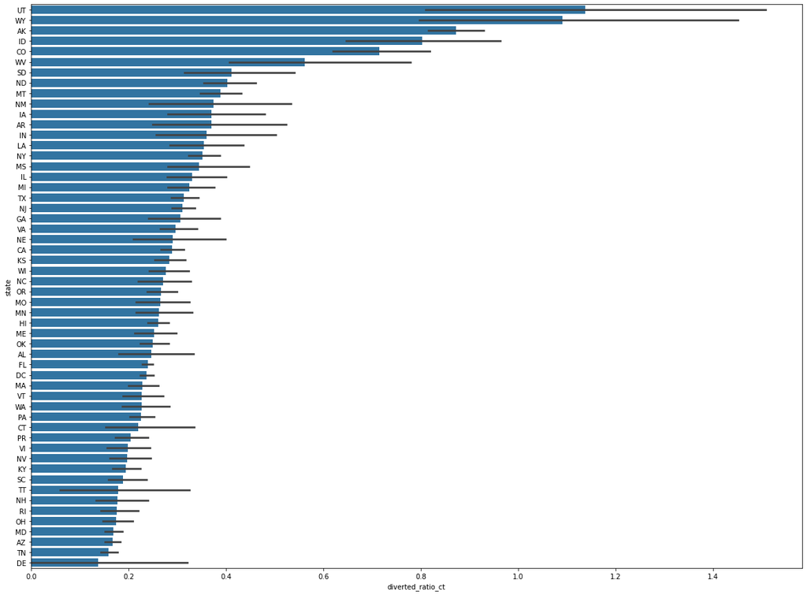

```python
order_CRstate = flights.groupby('state')['diverted_ratio_ct'].mean().sort_values(ascending=False).index.values

plt.figure(figsize = [20, 15])
sb.barplot(data=flights,  y='state',x='diverted_ratio_ct', color=base_color, order=order_CRstate);
```

In terms of cancellations, the highest are in the states of New Jersey, Maine and Illinois, while the least are located in Washingtong, Guam and Hawaii.

Finally, in terms of the % of diverted flights, on average the highest is located in Utah, Wyoming, and Alaska, and the least is in Arizona, Tennessee, and Delawere.

### Which are the airlines (carrier name) with the most and least % of delayed flights?

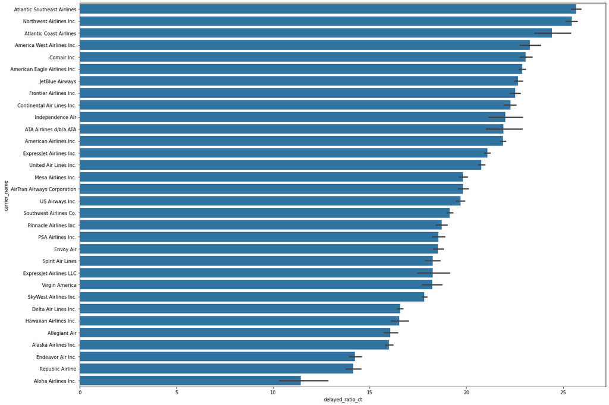

```python
order_DRcarrier = flights.groupby('carrier_name')['delayed_ratio_ct'].mean().sort_values(ascending=False).index.values

plt.figure(figsize = [20, 15])
sb.barplot(data=flights,  y='carrier_name',x='delayed_ratio_ct', color=base_color, order=order_DRcarrier);
```

### Which are the airlines (carrier name) with the most and least % of cancelled flights?

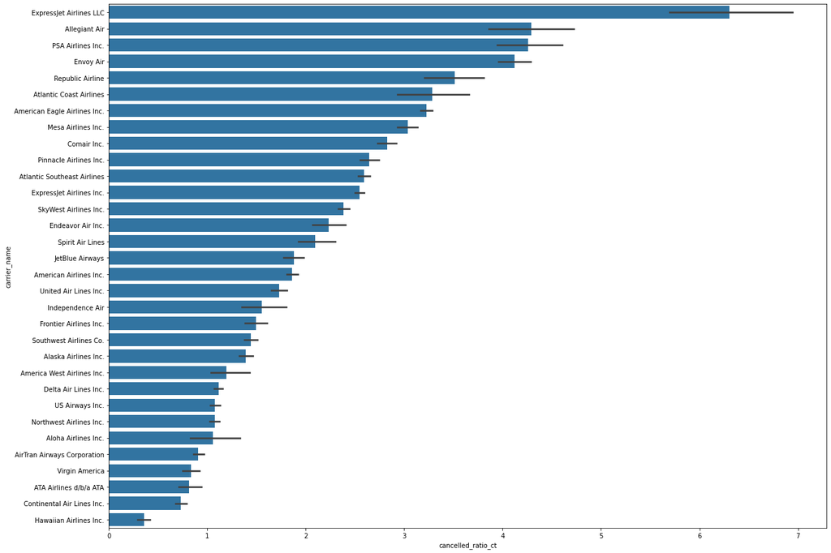

```python
order_CRcarrier = flights.groupby('carrier_name')['cancelled_ratio_ct'].mean().sort_values(ascending=False).index.values

plt.figure(figsize = [20, 15])
sb.barplot(data=flights,  y='carrier_name',x='cancelled_ratio_ct', color=base_color, order=order_CRcarrier);
```

### Which are the airlines (carrier name) with the most and least % of diverted flights?

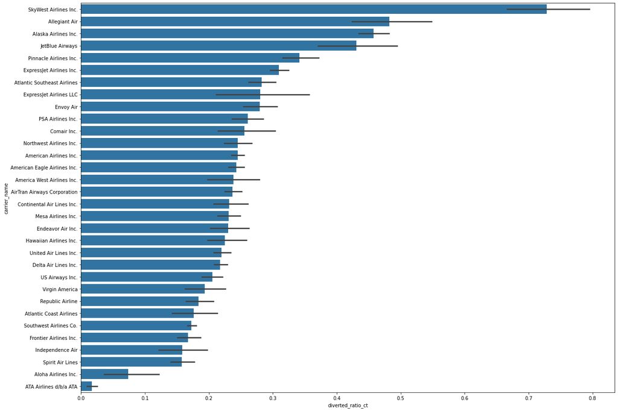

```python
order_DRcarrier = flights.groupby('carrier_name')['diverted_ratio_ct'].mean().sort_values(ascending=False).index.values

plt.figure(figsize = [20, 15])
sb.barplot(data=flights,  y='carrier_name',x='diverted_ratio_ct', color=base_color, order=order_DRcarrier);
```

Regarding the % of delays, the airlanes with the highest are Atlantic Southeast, Northwest Inc and Atlantic Coast, and the least % of delayed flights are Endeavor Air, Republic and Aloha Airlines Inc.

In terms of cancellations, the highest are the airlines of ExpressJet LLC, Allegiant Air and PSA Airlines Inc, while the least are ATA Airlines, Continental Air Lines and Hawaii Airlines Inc.

Finally, in terms of the % of diverted flights, on average the highest are SkyWest Airlines Inc, Allegiant Air, and Alaska Airlines, and the least is in Spirit Air Lines, Aloha Airlines Inc, and ATA Airlines.

### Talk about some of the relationships you observed in this part of the investigation. How did the feature(s) of interest vary with other features in the dataset?

Something that was not expected was the case with the nas and carrier types because on average a greater number of flights are delayed for nas reasons but the durations of delays per carrier are longer on average. This were the only types of delay that did not matched with their order in the count of the variables of queantity of delayed flights and durations of delays. Another interesting thing was to see how the % of the delays, calcellations and divertions varies along the months a visualize their seasonality. Also was useful to see the distribution of types of delay anually and see the effect of covid-19 in 2020.

## Multivariate Exploration

The main thing I want to explore in this part of the analysis is how the count of delays and durations of delays varies between types of delay. Also add the variable of month to analize posible seasonalities.

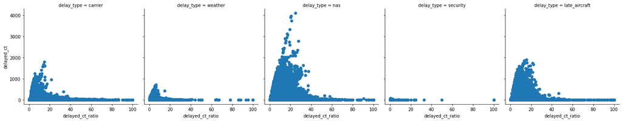

```python
g = sb.FacetGrid(data = fligts_ct_min, col = 'delay_type', height = 4, margin_titles = True)

g.map(plt.scatter, 'delayed_ct_ratio', 'delayed_ct');
```

In the 5 graphs, an accumulation between 0% and 30% of the percentage of delayed flights for each cause is observed, where the maximum values for the number of delayed flights are reached. This could indicate that if a large number of flights are delayed for any of the 5 reasons, these are usually a lower percentage than half of the total number of delayed flights, therefore, the higher the number of delayed flights, accompanied growth is expected. of all 5 causes of delay on different scales.

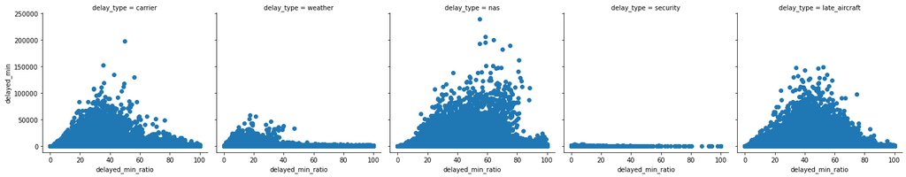

```python
g = sb.FacetGrid(data = fligts_ct_min, col = 'delay_type', height = 4, margin_titles = True)

g.map(plt.scatter, 'delayed_min_ratio', 'delayed_min');
```

In the case of the percentage of minutes delayed vs the number of minutes delayed for each cause, a relatively normal distribution can be seen in the carrier, nas and late_aircraft scenarios, while with weather the same relationship is manifested as described in with the count and percentage variables count. Regarding security, the result is due to the fact that the duration of its delays is almost zero.

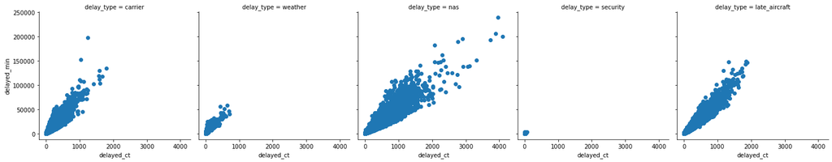

```python
g = sb.FacetGrid(data = fligts_ct_min, col = 'delay_type', height = 4, margin_titles = True)

g.map(plt.scatter, 'delayed_ct', 'delayed_min');
```

In the case of the number of delayed flights vs the number of minutes delayed for each cause, an almost completely linear relationship can be seen for all the type of delay scenarios except for security.

### How is behaviour of the % of flights delayed by month and type of delay?

```python
def mean_poly(x, y, bins = 0.1, **kwargs):
    """ Custom adapted line plot code. """
    # set bin edges if none or int specified
    if type(bins) == int:
        bins = np.linspace(x.min(), x.max(), bins+1)
    bin_centers = (bin_edges[1:] + bin_edges[:-1]) / 2
    # compute counts
    data_bins = pd.cut(x, bins, right = False,
                       include_lowest = True)
    means = y.groupby(data_bins).mean()
    # create plot
    plt.errorbar(x = bin_centers, y = means, **kwargs)
```

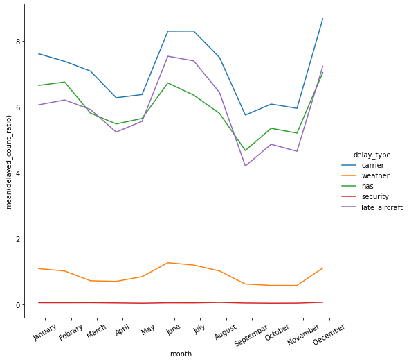

```python
bin_edges = np.arange(0.25, fligts_ct_min['month'].max()+0.5, 1)
g = sb.FacetGrid(data = fligts_ct_min, hue = 'delay_type', height = 7)
g.map(mean_poly, "month", "delayed_ct_ratio", bins = bin_edges)
g.set_ylabels('mean(delayed_count_ratio)')
g.add_legend()
plt.xticks([1,2,3,4,5,6,7,8,9,10,11,12], ['January','Febrary','March','April','May','June','July','August','September','October','November','December'])
plt.xticks(rotation='30');
```

### How is behaviour of the % of durations for delayed flights by month and type of delay?

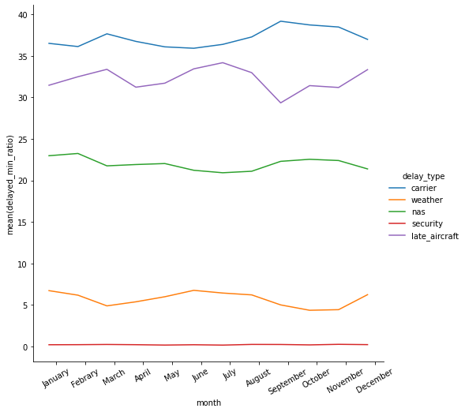

```python
bin_edges = np.arange(0.25, fligts_ct_min['month'].max()+0.5, 1)
g = sb.FacetGrid(data = fligts_ct_min, hue = 'delay_type', height = 7)
g.map(mean_poly, "month", "delayed_min_ratio", bins = bin_edges)
g.set_ylabels('mean(delayed_min_ratio)')
g.add_legend()
plt.xticks([1,2,3,4,5,6,7,8,9,10,11,12], ['January','Febrary','March','April','May','June','July','August','September','October','November','December'])
plt.xticks(rotation='30');
```

### Talk about some of the relationships you observed in this part of the investigation. Were there features that strengthened each other in terms of looking at your feature(s) of interest?

The most interesting relationship was that between 0% and 30% of the percentage of delayed flights for each cause, where the maximum values for the number of delayed flights are reached. This could indicate that if a large number of flights are delayed for any of the 5 reasons, these are usually a lower percentage than half of the total number of delayed flights, therefore, the higher the number of delayed flights, accompanied growth is expected of all 5 causes of delay on different scales.